# Invent the Future

# Todo:

- Write down better introduction
- Fix packages
- add text about importance of feature extraction

# input:

- features: (samples x 32830/925032 gene/probeset) RNAseq counts (+extracted features); data has been batch and count normalized
- class: (367 train sample) gestational age 8-42 weeks

# output:

- class: (368 test sample) gestational age 8-42 weeks rounded to 1 decimal place

# Data Analysis

## 1. Preprocessing

In the first part we will work on the environment we will use. This means we will clean the environment, declare the directory of the project and install libraries.

```r
rm(list=ls(all=T)) # clean the environment
set.seed(10)
## Defining the work directory of the project
#root = "/mnt/f/Brinkman group/current/Alice/ai4all2019_bio"
root = "C:\\Users\\raoki\\Documents\\GitHub\\ai4all2019_bio"
setwd(root)
## Creating sub directories to save data, features, model and results
input_dir = paste0(root,"/00_input") # raw data directory
feat_dir = paste0(root,"/01_features") # feature directory
model_dir = paste0(root, "/02_models") # model directory
result_dir = paste0(root, "/03_results") # stats/plots directory
sapply(c(input_dir,feat_dir, model_dir, result_dir),
       function(x) dir.create(x, showWarnings=F))
## load packages; need to fix according to what model we'll be using
pkgs = c("Rfast", "stringr", "plyr", "dplyr", "Matrix", # var, str_, llply, etc
         "lattice", "ggplot2", "grid","gridExtra", # barplot, plots
         "foreach", "doMC", # parallel back-end
         "caret", "e1071", "ranger", "ANN2", "randomForest",
         "elasticnet", "fastICA", "foba", "glmnet","kernlab",
         "KRLS", "lars", "leaps", "nnls", "nodeHarvest",
         "partDSA", "pls", "plsRglm", "rpart", "rqPen",
         "RSNNS", "spikeslab", "xgboost") # ml
pkgs_ui = setdiff(pkgs, rownames(installed.packages()))
if (length(pkgs_ui) > 0) install.packages(pkgs_ui, verbose=F)
sapply(pkgs, require, character.only=T)
## script options
#no_cores = detectCores()-1 # number of cores to use in parallel
#registerDoMC(no_cores)
#overwrite = F # overwrite results?
```

Next, we will load the input files. There are 3 files:

1. Sample Annotation file:
- SampleID: unique identifier of the sample (matching the name of the .CEL file in HTA20 folder, except for extension .CEL);
- GA: gestational age as determined by the last menstrual period and or ultrasound;
- Batch: the batch identifier;
- Set: name of the source dataset;
- Train: 1 for samples to be used for training, 0 for samples to be used for test;
2. RNASEQ Data: each row is a gene and each column a patient
- probeset: gene ID
- pid: patient id
3. Submission template for the competition

```r
## load input files
#Sample Annotation file
meta=  read.csv(paste0(input_dir,"/anoSC1_v11_nokey.csv"))
# RNASEQ data
data0 = t(get(load(paste0(input_dir,"/HTA20_RMA.RData"))))
# submission template
submission = read.csv(paste0(input_dir,"/TeamX_SC1_prediction.csv"))
```

Data Exploration:

```r
cat('Range\n');range(data0) ; cat('Genes IDs\n');gid = colnames(data0); head(gid) ;cat('Patients IDs\n');pid = rownames(data0); head(pid)
```

```
Range
[1]  0.9365626 14.2836285
Genes IDs
[1] "1_at"         "10_at"        "100_at"       "1000_at"      "10000_at"     "100009613_at"
Patients IDs
[1] "Tarca_001_P1A01" "Tarca_003_P1A03" "Tarca_004_P1A04" "Tarca_005_P1A05" "Tarca_006_P1A06" "Tarca_007_P1A07"
```

```r
cat('Meta Data head and shape\n'); head(meta); dim(meta)
```

```
Meta Data head and shape
```

|  | SampleID | GA | Batch | Set | Train | Platform |
| --- | --- | --- | --- | --- | --- | --- |
| 1 | Tarca_001_P1A01 | 11.0 | 1 | PRB_HTA | 1 | HTA20 |
| 2 | Tarca_013_P1B01 | 15.3 | 1 | PRB_HTA | 1 | HTA20 |
| 3 | Tarca_025_P1C01 | 21.7 | 1 | PRB_HTA | 1 | HTA20 |
| 4 | Tarca_037_P1D01 | 26.7 | 1 | PRB_HTA | 1 | HTA20 |
| 5 | Tarca_049_P1E01 | 31.3 | 1 | PRB_HTA | 1 | HTA20 |
| 6 | Tarca_061_P1F01 | 32.1 | 1 | PRB_HTA | 1 | HTA20 |

```
[1] 735   6
```

```r
cat('RNASEQ head and shape\n'); head(data0[,c(1:5)]); dim(data0)
```

```
RNASEQ head and shape
                    1_at    10_at   100_at  1000_at 10000_at
Tarca_001_P1A01 6.062215 3.796484 5.849338 3.567779 6.166815
Tarca_003_P1A03 6.125023 3.805305 6.191562 3.452524 5.678373
Tarca_004_P1A04 5.875502 3.450245 6.550525 3.316134 6.185059
Tarca_005_P1A05 6.126131 3.628411 6.421877 3.432451 5.633757
Tarca_006_P1A06 6.146466 3.446812 6.260962 3.477162 5.313198
Tarca_007_P1A07 6.134555 3.512325 6.154893 3.638140 5.148149
[1]   735 32830
```

```r
cat('Submission head and shape\n'); head(submission); dim(submission)
```

```
Submission head and shape
```

|  | SampleID | GA |
| --- | --- | --- |
| 1 | Tarca_074_P1G02 | NA |
| 2 | Tarca_086_P1H02 | NA |
| 3 | Tarca_003_P1A03 | NA |
| 4 | Tarca_015_P1B03 | NA |
| 5 | Tarca_027_P1C03 | NA |
| 6 | Tarca_039_P1D03 | NA |

```
[1] 368   2
```

Now we will explore the data with some plots. First we need to prepare the data and summarize the informatoin we will use in the plots.

```r
# plot stats: mean count, pearson/spearman corr
#Using only the train dataset to calculate the correlation, mean and variance
data1 = data.frame('SampleID' = rownames(data0), data0)
data1 = merge(meta[,c(1,2,5)],data1,by.x = 'SampleID',by.y = 'SampleID', all = T)
#splitting training set and testing set
data1 = subset(data1, Train == 1)
data1 = subset(data1, select = -c(Train,SampleID))
#train set
data_cor = data.frame(col = names(data1),corr_p = apply(data1, 2, cor, x = data1$GA, method = 'pearson'))
data_cor = data.frame(data_cor, corr_s = apply(data1, 2, cor, x = data1$GA, method = 'spearman'))
rownames(data_cor) = NULL
#Dataset with all information
data_cor = data.frame(data_cor, variance = c(var(data1$GA),colVars(data0)), mean = c(mean(data1$GA),colMeans(data0)))
data_cor = data_cor[-1,] # removing GA from the dataset
```

To make the plots, we will use a library called ggplot2. Here are shown some plots we can make using this library.

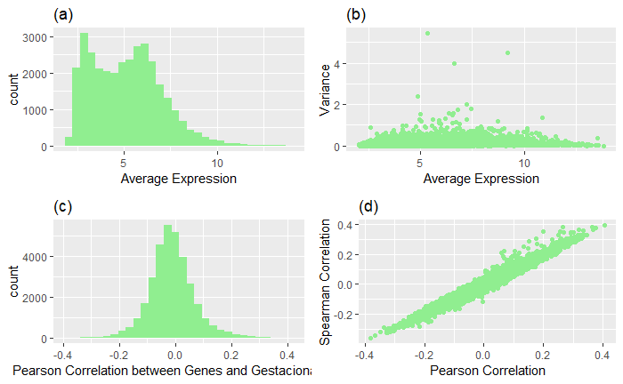

```r
# plot stats
p1 <- ggplot(data_cor, aes(x=mean)) +
  geom_histogram(fill = 'lightgreen') +
  xlab('Average Expression') + labs(title='(a)')
p2 <- ggplot(data_cor, aes(x=mean, y = variance)) +
  geom_point(color = 'lightgreen')+
  xlab('Average Expression') +
  ylab('Variance')+ labs(title='(b)')
p3 <- ggplot(data_cor, aes(x=corr_p)) +
  geom_histogram(fill = 'lightgreen')+
  xlab('Pearson Correlation between Genes and Gestacional Age')+ labs(title='(c)')
p4 <- ggplot(data_cor, aes(x=corr_p, y = corr_s)) +
  geom_point(color = 'lightgreen')+ labs(title='(d)')+
  xlab('Pearson Correlation') + ylab('Spearman Correlation')
grid.arrange(p1, p2, p3, p4, nrow = 2)
```